# Annual Census Analysis

Brandie Quarles

2023-09-14

To Do:

- Add climate to the models!

Original Design - 23 pops, 7 mfs, 13 reps

- Note: this analysis is for transplant beds only

## Questions:

- Is there more variation b/t populations than b/t mfs?
- Are certain traits related to fitness?
- Did low elevation populations perform better than high elevation populations?
- Connection to climate of home site?

## Relevant Libraries and Functions

```r
library(tidyverse)
library(tidymodels)
tidymodels_prefer()
library(lmerTest) #for mixed effect models
conflicted::conflicts_prefer(lmerTest::lmer)
```

```
## [conflicted] Will prefer lmerTest::lmer over any other package.
```

```r
library(broom.mixed) #tidy method for lmerTest and glmer
library(corrplot) #plotting correlations
library(rstatix) #performing cor_test
library(naniar) #replaces values with NA
sem <- function(x, na.rm=FALSE) {
  sd(x,na.rm=na.rm)/sqrt(length(na.omit(x)))
} #standard error function

elev_three_palette <- c("#0043F0", "#C9727F", "#F5A540") #colors from Gremer et al 2019
elev_order <- c("High", "Mid", "Low")

#For scree plots
#library("devtools") #The package devtools is required for the installation as factoextra is hosted on github.
#1install_github("kassambara/factoextra")
library("factoextra")
```

## Load the pop and location data

```r
#pop info
pops_common_garden <- read_csv("../input/UCD_Data/Pops_for_2022_UCD.csv") #pops included in common garden
summary(pops_common_garden)
```

```
##   parent.pop          phylogroup    elevation.group    maternal.families
##  Length:23          Min.   :1.000   Length:23          Min.   : 3.0
##  Class :character   1st Qu.:2.000   Class :character   1st Qu.:16.5
##  Mode  :character   Median :4.000   Mode  :character   Median :23.0
##                     Mean   :4.435                      Mean   :22.7
##                     3rd Qu.:7.000                      3rd Qu.:29.5
##                     Max.   :9.000                      Max.   :44.0
##  approx.number.seeds UCD.seed.year  proposed.WL2.seed.year collection.priority.
##  Min.   : 100.0      Min.   :2014   Min.   :2014           Length:23
##  1st Qu.: 500.0      1st Qu.:2018   1st Qu.:2020           Class :character
##  Median : 500.0      Median :2020   Median :2021           Mode  :character
##  Mean   : 608.7      Mean   :2020   Mean   :2020
##  3rd Qu.:1000.0      3rd Qu.:2021   3rd Qu.:2021
##  Max.   :1000.0      Max.   :2021   Max.   :2022
##  on.climate.PCA.    JGI.DNA           notes
##  Length:23          Mode:logical   Length:23
##  Class :character   NA's:23        Class :character
##  Mode  :character                  Mode  :character
##
##
##
```

```r
pops_common_garden_nonotes <- pops_common_garden %>% select(parent.pop:elevation.group, UCD.seed.year)
pops_common_garden_nonotes$elevation.group <- str_to_title(pops_common_garden_nonotes$elevation.group)

#extra location info
pop_loc <- read_csv("../input/Strep_tort_locs.csv")
unique(pop_loc$`Site code`)
```

```
##  [1] "BH"     "BB"     "CC"     "CP1"    "CP2"    "CP3"    "DP"     "DPR"
##  [9] "FR"     NA       "HH"     "IH"     "KC1"    "KC2"    "KC3"    "LV1"
## [17] "LV2"    "LV3"    "LVTR1"  "LVTR2"  "LVTR3"  "SQ1"    "SQ2"    "SQ3"
## [25] "SHA"    "SC"     "TM1"    "TM2"    "WR"     "WV"     "WL1"    "WL2"
## [33] "WL3"    "WL4"    "YOSE1"  "YOSE10" "YOSE11" "YOSE12" "YOSE13" "YOSE2"
## [41] "YOSE3"  "YOSE4"  "YOSE5"  "YOSE6"  "YOSE7"  "YOSE8"  "YOSE9"
```

```r
unique(pops_common_garden_nonotes$parent.pop)
```

```
##  [1] "BH"    "CC"    "CP2"   "CP3"   "DPR"   "FR"    "IH"    "LV1"   "LV3"
## [10] "LVTR1" "SC"    "SQ1"   "SQ2"   "SQ3"   "TM2"   "WL1"   "WL2"   "WR"
## [19] "WV"    "YO11"  "YO4"   "YO7"   "YO8"
```

```r
#need to change YOSE to YO
pop_loc_yo <- pop_loc %>% mutate(parent.pop = str_replace(`Site code`, "YOSE(\\d+)", "YO\\1")) %>% select(Lat, Long, elev_m=`Elevation (m)`, parent.pop)
unique(pop_loc_yo$parent.pop)
```

```
##  [1] "BH"    "BB"    "CC"    "CP1"   "CP2"   "CP3"   "DP"    "DPR"   "FR"
## [10] NA      "HH"    "IH"    "KC1"   "KC2"   "KC3"   "LV1"   "LV2"   "LV3"
## [19] "LVTR1" "LVTR2" "LVTR3" "SQ1"   "SQ2"   "SQ3"   "SHA"   "SC"    "TM1"
## [28] "TM2"   "WR"    "WV"    "WL1"   "WL2"   "WL3"   "WL4"   "YO1"   "YO10"
## [37] "YO11"  "YO12"  "YO13"  "YO2"   "YO3"   "YO4"   "YO5"   "YO6"   "YO7"
## [46] "YO8"   "YO9"
```

```r
#merge in location info
pop_elev <- left_join(pops_common_garden_nonotes, pop_loc_yo)
head(pop_elev)
```

```
## # A tibble: 6 × 7
##   parent.pop phylogroup elevation.group UCD.seed.year Lat      Long       elev_m
##   <chr>           <dbl> <chr>                   <dbl> <chr>    <chr>       <dbl>
## 1 BH                  4 Low                      2021 37.40985 -119.96458   511.
## 2 CC                  7 Low                      2018 39.58597 -121.43311   313
## 3 CP2                 2 High                     2019 38.66169 -120.13065  2244.
## 4 CP3                 2 High                     2018 38.70649 -120.08797  2266.
## 5 DPR                 5 Mid                      2020 39.22846 -120.81518  1019.
## 6 FR                  7 Mid                      2019 40.01362 -121.18498   787
```

## Load the annual census data

```r
#Note: BQC edited the csvs prior to importing to R b/c the first row of the transplants sheets was not the heading row (veg, repo info and not block, mf etc...)
anncensustrans.0522 <- read_csv("../input/UCD_Data/CorrectedCSVs/Annual_Census_Transplants_All_May_2023_corrected.csv")
names(anncensustrans.0522) <- gsub(" ", "", colnames(anncensustrans.0522))
anncensustrans.0522 %>% rowwise() %>% filter(!is.na(mf)) %>% filter(is.na(as.numeric(mf))) #mf = X when pop = buffer
```

```
## # A tibble: 5 × 19
## # Rowwise:
##   date  block   row col   pop   mf    rep   pheno diam_mm height_cm total_branch
##   <chr> <chr> <dbl> <chr> <chr> <chr> <chr> <chr>   <dbl>     <dbl>        <dbl>
## 1 5/22… J1        0 C     buff… X     X     X          NA        NA           NA
## 2 5/22… J1        1 C     buff… X     X     X          NA        NA           NA
## 3 5/22… J1        1 D     buff… X     X     X          NA        NA           NA
## 4 5/22… J1        2 C     buff… X     X     X          NA        NA           NA
## 5 5/22… J1        2 D     buff… X     X     X          NA        NA           NA
## # ℹ 8 more variables: herb_dam <chr>, wilt_status <chr>, longest_leaf_cm <dbl>,
## #   flowers <dbl>, fruits <dbl>, longest_fruit_cm <dbl>, repro_branch <dbl>,
## #   notes <chr>
```

```r
anncensustrans.0522 %>% rowwise() %>% filter(!is.na(rep)) %>% filter(is.na(as.numeric(rep)))
```

```
## # A tibble: 5 × 19
## # Rowwise:
##   date  block   row col   pop   mf    rep   pheno diam_mm height_cm total_branch
##   <chr> <chr> <dbl> <chr> <chr> <chr> <chr> <chr>   <dbl>     <dbl>        <dbl>
## 1 5/22… J1        0 C     buff… X     X     X          NA        NA           NA
## 2 5/22… J1        1 C     buff… X     X     X          NA        NA           NA
## 3 5/22… J1        1 D     buff… X     X     X          NA        NA           NA
## 4 5/22… J1        2 C     buff… X     X     X          NA        NA           NA
## 5 5/22… J1        2 D     buff… X     X     X          NA        NA           NA
## # ℹ 8 more variables: herb_dam <chr>, wilt_status <chr>, longest_leaf_cm <dbl>,
## #   flowers <dbl>, fruits <dbl>, longest_fruit_cm <dbl>, repro_branch <dbl>,
## #   notes <chr>
```

```r
anncensustrans.0522 %>% filter(pheno != "X" & is.na(diam_mm)) #no living plants without a diameter
```

```
## # A tibble: 0 × 19
## # ℹ 19 variables: date <chr>, block <chr>, row <dbl>, col <chr>, pop <chr>,
## #   mf <chr>, rep <chr>, pheno <chr>, diam_mm <dbl>, height_cm <dbl>,
## #   total_branch <dbl>, herb_dam <chr>, wilt_status <chr>,
## #   longest_leaf_cm <dbl>, flowers <dbl>, fruits <dbl>, longest_fruit_cm <dbl>,
## #   repro_branch <dbl>, notes <chr>
```

```r
anncensustrans.0522_alive <- anncensustrans.0522 %>% filter(!is.na(diam_mm)) %>% mutate_at(c("mf", "rep"), as.double) #used diameter instead of pheno to filter b/c some dying plants were measured
summary(anncensustrans.0522_alive)
```

```
##      date              block                row            col
##  Length:64          Length:64          Min.   : 3.00   Length:64
##  Class :character   Class :character   1st Qu.:13.00   Class :character
##  Mode  :character   Mode  :character   Median :24.50   Mode  :character
##                                        Mean   :21.70
##                                        3rd Qu.:30.25
##                                        Max.   :41.00
##
##      pop                  mf             rep            pheno
##  Length:64          Min.   :1.000   Min.   :  1.00   Length:64
##  Class :character   1st Qu.:3.000   1st Qu.:  4.00   Class :character
##  Mode  :character   Median :4.000   Median :  9.00   Mode  :character
##                     Mean   :4.094   Mean   : 10.06
##                     3rd Qu.:5.000   3rd Qu.: 12.00
##                     Max.   :8.000   Max.   :100.00
##
##     diam_mm        height_cm       total_branch      herb_dam
##  Min.   : 2.19   Min.   :  5.50   Min.   : 1.000   Length:64
##  1st Qu.: 7.13   1st Qu.: 16.32   1st Qu.: 1.000   Class :character
##  Median :11.49   Median : 30.00   Median : 1.000   Mode  :character
##  Mean   :11.38   Mean   : 35.23   Mean   : 2.594
##  3rd Qu.:14.79   3rd Qu.: 50.65   3rd Qu.: 3.250
##  Max.   :23.35   Max.   :109.50   Max.   :13.000
##
##  wilt_status        longest_leaf_cm     flowers           fruits
##  Length:64          Min.   : 1.200   Min.   :  0.00   Min.   :  0.00
##  Class :character   1st Qu.: 4.075   1st Qu.:  0.00   1st Qu.:  0.00
##  Mode  :character   Median : 6.150   Median :  0.00   Median :  0.00
##                     Mean   : 5.971   Mean   : 12.55   Mean   : 46.17
##                     3rd Qu.: 7.450   3rd Qu.: 10.00   3rd Qu.:  3.00
##                     Max.   :10.100   Max.   :149.00   Max.   :661.00
##                     NA's   :30
##  longest_fruit_cm  repro_branch     notes
##  Min.   : 0.000   Min.   :0.00   Length:64
##  1st Qu.: 0.000   1st Qu.:0.00   Class :character
##  Median : 0.000   Median :1.00   Mode  :character
##  Mean   : 1.741   Mean   :0.75
##  3rd Qu.: 2.700   3rd Qu.:1.00
##  Max.   :10.800   Max.   :4.00
##  NA's   :3        NA's   :4
```

```r
anncensustrans.0626 <- read_csv("../input/UCD_Data/CorrectedCSVs/Annual_Census_transplants_20230626_corrected.csv")
names(anncensustrans.0626) <- gsub(" ", "", colnames(anncensustrans.0626))
anncensustrans.0626 %>% filter(pheno == "X" & !is.na(diam_mm)) #no dead plants that have size info
```

```
## # A tibble: 0 × 19
## # ℹ 19 variables: date <chr>, block <chr>, row <dbl>, col <chr>, pop <chr>,
## #   mf <dbl>, rep <dbl>, pheno <chr>, diam_mm <dbl>, height_cm <dbl>,
## #   total_branch <dbl>, herb_dam <chr>, wilt_status <chr>,
## #   longest_leaf_cm <dbl>, flowers <dbl>, fruits <dbl>, longest_fruit_cm <dbl>,
## #   repro_branch <dbl>, notes <chr>
```

```r
anncensustrans.0626_alive <- anncensustrans.0626 %>% filter(pheno != "X")
summary(anncensustrans.0626_alive) #56 plants alive
```

```
##      date              block                row            col
##  Length:56          Length:56          Min.   : 3.00   Length:56
##  Class :character   Class :character   1st Qu.:12.25   Class :character
##  Mode  :character   Mode  :character   Median :25.00   Mode  :character
##                                        Mean   :21.73
##                                        3rd Qu.:31.00
##                                        Max.   :41.00
##
##      pop                  mf             rep            pheno
##  Length:56          Min.   :1.000   Min.   :  1.00   Length:56
##  Class :character   1st Qu.:3.000   1st Qu.:  4.00   Class :character
##  Mode  :character   Median :4.000   Median :  9.00   Mode  :character
##                     Mean   :4.054   Mean   : 10.39
##                     3rd Qu.:5.000   3rd Qu.: 12.25
##                     Max.   :8.000   Max.   :100.00
##
##     diam_mm        height_cm       total_branch      herb_dam
##  Min.   : 3.59   Min.   :  5.80   Min.   : 1.000   Length:56
##  1st Qu.:10.45   1st Qu.: 20.77   1st Qu.: 1.000   Class :character
##  Median :14.24   Median : 36.00   Median : 1.500   Mode  :character
##  Mean   :15.12   Mean   : 43.83   Mean   : 2.946
##  3rd Qu.:19.34   3rd Qu.: 64.92   3rd Qu.: 4.250
##  Max.   :35.67   Max.   :111.90   Max.   :11.000
##  NA's   :5
##  wilt_status        longest_leaf_cm    flowers           fruits
##  Length:56          Min.   :1.200   Min.   :  0.00   Min.   :  0.00
##  Class :character   1st Qu.:3.100   1st Qu.:  3.00   1st Qu.:  3.25
##  Mode  :character   Median :5.100   Median :  7.00   Median : 62.00
##                     Mean   :5.176   Mean   : 19.43   Mean   :151.37
##                     3rd Qu.:6.700   3rd Qu.: 22.75   3rd Qu.:261.00
##                     Max.   :9.500   Max.   :183.00   Max.   :508.00
##                     NA's   :27      NA's   :26       NA's   :26
##  longest_fruit_cm  repro_branch      notes
##  Min.   : 1.300   Min.   :0.000   Length:56
##  1st Qu.: 6.000   1st Qu.:0.000   Class :character
##  Median : 8.400   Median :1.000   Mode  :character
##  Mean   : 7.789   Mean   :1.036
##  3rd Qu.: 9.700   3rd Qu.:1.000
##  Max.   :12.900   Max.   :7.000
##  NA's   :29
```

```r
#quick summary info
levels(as.factor(anncensustrans.0522_alive$pop)) #out of 23 pops, only 10 alive still (BH, CP2, DPR, IH, SC, SQ3, TM2, WL1, WL2, YO7)
```

```
##  [1] "BH"  "CP2" "DPR" "IH"  "SC"  "SQ3" "TM2" "WL1" "WL2" "YO7"
```

```r
levels(as.factor(anncensustrans.0626_alive$pop)) #only 9 pops alive (no DPR)
```

```
## [1] "BH"  "CP2" "IH"  "SC"  "SQ3" "TM2" "WL1" "WL2" "YO7"
```

```r
#B = budding
#F = floweirng
#P = post flowering (has fruits)
#S = senescing (applies to TM2 only)
#V = vegetative
xtabs(~pheno+pop, data = anncensustrans.0522_alive)
```

```
##      pop
## pheno BH CP2 DPR IH SC SQ3 TM2 WL1 WL2 YO7
##     B  6   1   0  0  1   0   0   0   0   0
##     F  2   0   0  0  0   1   0   0   0   0
##     P  5   0   0  0  1   0   8   0   1   0
##     V 18   2   0  4  2   0   0   1   3   2
##     X  0   0   2  0  0   0   4   0   0   0
```

```r
xtabs(~pheno+pop, data = anncensustrans.0626_alive) #vegetative decreases for BH & CP2 --> may have reproductive data for some new individuals
```

```
##      pop
## pheno BH CP2 IH SC SQ3 TM2 WL1 WL2 YO7
##     B  0   0  0  1   0   0   0   0   0
##     F  2   0  0  0   0   0   0   0   0
##     P 15   1  0  1   1   0   0   1   0
##     S  0   0  0  0   0   8   0   0   0
##     V 13   1  4  2   0   0   1   3   2
```

## Prep for Merge

```r
anncensustrans_0522_alive_tomerge <- anncensustrans.0522_alive %>% select(block:col, parent.pop=pop, mf:rep, pheno.0522=pheno, diam.0522=diam_mm, height.0522=height_cm, total_branch.0522=total_branch, herb_dam.0522=herb_dam, wilt_status.0522=wilt_status, longest_leaf.0522=longest_leaf_cm, flowers.0522=flowers, fruits.0522=fruits, longest_fruit.0522=longest_fruit_cm, repro_branch.0522=repro_branch)
names(anncensustrans_0522_alive_tomerge)
```

```
##  [1] "block"              "row"                "col"
##  [4] "parent.pop"         "mf"                 "rep"
##  [7] "pheno.0522"         "diam.0522"          "height.0522"
## [10] "total_branch.0522"  "herb_dam.0522"      "wilt_status.0522"
## [13] "longest_leaf.0522"  "flowers.0522"       "fruits.0522"
## [16] "longest_fruit.0522" "repro_branch.0522"
```

```r
anncensustrans_0626_alive_tomerge <- anncensustrans.0626_alive %>% select(block:col, parent.pop=pop, mf:rep, pheno.0626=pheno, diam.0626=diam_mm, height.0626=height_cm, total_branch.0626=total_branch, herb_dam.0626=herb_dam, wilt_status.0626=wilt_status, longest_leaf.0626=longest_leaf_cm, flowers.0626=flowers, fruits.0626=fruits, longest_fruit.0626=longest_fruit_cm, repro_branch.0626=repro_branch)
names(anncensustrans_0626_alive_tomerge)
```

```
##  [1] "block"              "row"                "col"
##  [4] "parent.pop"         "mf"                 "rep"
##  [7] "pheno.0626"         "diam.0626"          "height.0626"
## [10] "total_branch.0626"  "herb_dam.0626"      "wilt_status.0626"
## [13] "longest_leaf.0626"  "flowers.0626"       "fruits.0626"
## [16] "longest_fruit.0626" "repro_branch.0626"
```

## Merge dataframes

- Combine 0522 and 0626
  - if an individual is sampled twice use the maximum value - add in pop elevation info

```r
anncensustrans_all_alive <- full_join(anncensustrans_0522_alive_tomerge, anncensustrans_0626_alive_tomerge)
dim(anncensustrans_all_alive) #64 rows , 28 cols
```

```
## [1] 64 28
```

```r
#convert to long
anncensustrans_all_alive_long <- reshape(anncensustrans_all_alive, direction = "long", sep = ".",
                                      idvar=c("block", "row", "col", "parent.pop", "mf", "rep"),
                                      varying =c("pheno.0522", "diam.0522", "height.0522", "total_branch.0522", "herb_dam.0522", "wilt_status.0522", "longest_leaf.0522", "flowers.0522", "fruits.0522", "longest_fruit.0522", "repro_branch.0522", "pheno.0626", "diam.0626", "height.0626", "total_branch.0626", "herb_dam.0626", "wilt_status.0626", "longest_leaf.0626", "flowers.0626", "fruits.0626", "longest_fruit.0626", "repro_branch.0626"))
dim(anncensustrans_all_alive_long)
```

```
## [1] 128  18
```

```r
anncensustrans_all_alive_max <- anncensustrans_all_alive_long %>%
  group_by(block, row, col, parent.pop, mf, rep) %>%
  summarise_if(is.double, max, na.rm=TRUE) %>%
  select(-time)
head(anncensustrans_all_alive_max) #some cases where max of different variables comes from different dates
```

```
## # A tibble: 6 × 14
## # Groups:   block, row, col, parent.pop, mf [6]
##   block   row col   parent.pop    mf   rep  diam height total_branch
##   <chr> <dbl> <chr> <chr>      <dbl> <dbl> <dbl>  <dbl>        <dbl>
## 1 D1        4 D     YO7            8     1  7.83    8.3            9
## 2 D2       26 B     BH             5    15 15.2    66.6            7
## 3 D2       29 C     BH             4    13 24.1    26.8            3
## 4 D2       29 D     BH             2     9 12.5    38.1            3
## 5 D2       30 B     BH             4     3 18.6    65              5
## 6 D2       31 B     TM2            4    11 12.9    59.4            1
## # ℹ 5 more variables: longest_leaf <dbl>, flowers <dbl>, fruits <dbl>,
## #   longest_fruit <dbl>, repro_branch <dbl>
```

```r
summary(anncensustrans_all_alive_max) #getting -Inf for longest_leaf and repro_branch b/c N/A at both times
```

```
##     block                row            col             parent.pop
##  Length:64          Min.   : 3.00   Length:64          Length:64
##  Class :character   1st Qu.:13.00   Class :character   Class :character
##  Mode  :character   Median :24.50   Mode  :character   Mode  :character
##                     Mean   :21.70
##                     3rd Qu.:30.25
##                     Max.   :41.00
##        mf             rep              diam           height
##  Min.   :1.000   Min.   :  1.00   Min.   : 3.59   Min.   :  5.50
##  1st Qu.:3.000   1st Qu.:  4.00   1st Qu.: 8.70   1st Qu.: 21.35
##  Median :4.000   Median :  9.00   Median :13.03   Median : 38.30
##  Mean   :4.094   Mean   : 10.06   Mean   :14.05   Mean   : 44.15
##  3rd Qu.:5.000   3rd Qu.: 12.00   3rd Qu.:17.41   3rd Qu.: 65.20
##  Max.   :8.000   Max.   :100.00   Max.   :35.67   Max.   :111.90
##   total_branch     longest_leaf       flowers           fruits
##  Min.   : 1.000   Min.   :  -Inf   Min.   :  0.00   Min.   :  0.00
##  1st Qu.: 1.000   1st Qu.:  -Inf   1st Qu.:  0.00   1st Qu.:  0.00
##  Median : 2.000   Median : 2.950   Median :  0.50   Median :  0.00
##  Mean   : 3.328   Mean   :  -Inf   Mean   : 17.84   Mean   : 80.97
##  3rd Qu.: 5.000   3rd Qu.: 6.625   3rd Qu.: 20.25   3rd Qu.: 44.00
##  Max.   :13.000   Max.   :10.100   Max.   :183.00   Max.   :661.00
##  longest_fruit    repro_branch
##  Min.   : -Inf   Min.   :-Inf
##  1st Qu.: 0.00   1st Qu.:   0
##  Median : 0.00   Median :   1
##  Mean   : -Inf   Mean   :-Inf
##  3rd Qu.: 6.95   3rd Qu.:   1
##  Max.   :12.90   Max.   :   7
```

```r
#anncensustrans_all_alive_max %>% filter(longest_leaf==-Inf)
#anncensustrans_all_alive_long %>% filter(block=="D1", row==4)
#head(anncensustrans_all_alive_max)

#add in pop elevation info
anncensustrans_all_alive_max_elev <- left_join(anncensustrans_all_alive_max, pop_elev)
names(anncensustrans_all_alive_max_elev)
```

```
##  [1] "block"           "row"             "col"             "parent.pop"
##  [5] "mf"              "rep"             "diam"            "height"
##  [9] "total_branch"    "longest_leaf"    "flowers"         "fruits"
## [13] "longest_fruit"   "repro_branch"    "phylogroup"      "elevation.group"
## [17] "UCD.seed.year"   "Lat"             "Long"            "elev_m"
```

```r
anncensustrans_all_alive_max_elev %>% group_by(parent.pop, mf) %>%
  filter(!is.na(diam)) %>%
  summarise(n=n()) #low replication at maternal family level
```

```
## # A tibble: 27 × 3
## # Groups:   parent.pop [10]
##    parent.pop    mf     n
##    <chr>      <dbl> <int>
##  1 BH             1     1
##  2 BH             2     5
##  3 BH             3     7
##  4 BH             4     8
##  5 BH             5     6
##  6 BH             6     2
##  7 BH             7     2
##  8 CP2            1     1
##  9 CP2            3     2
## 10 DPR            5     1
## # ℹ 17 more rows
```

```r
anncensustrans_all_alive_max_elev_noinf <- anncensustrans_all_alive_max_elev %>%
  mutate_if(is.double, list(~na_if(., -Inf))) %>%  #replace -INf with NAs
  filter(parent.pop != "WL1") %>%                  #take out pops with only 1 individual alive
  filter(parent.pop != "SQ3") %>%
  mutate(longest_fruit = na_if(longest_fruit, 0)) %>%  #change 0 branches to NA
  filter(rep != 100) #get rid of individuals that germinated in the field
```

```
## `mutate_if()` ignored the following grouping variables:
## • Columns `block`, `row`, `col`, `parent.pop`, `mf`
```

```r
summary(anncensustrans_all_alive_max_elev_noinf)
```

```
##     block                row           col             parent.pop
##  Length:61          Min.   : 3.0   Length:61          Length:61
##  Class :character   1st Qu.:13.0   Class :character   Class :character
##  Mode  :character   Median :25.0   Mode  :character   Mode  :character
##                     Mean   :22.1
##                     3rd Qu.:30.0
##                     Max.   :41.0
##
##        mf             rep              diam           height
##  Min.   :1.000   Min.   : 1.000   Min.   : 3.67   Min.   :  5.50
##  1st Qu.:3.000   1st Qu.: 4.000   1st Qu.: 8.87   1st Qu.: 24.50
##  Median :4.000   Median : 9.000   Median :13.67   Median : 43.00
##  Mean   :4.148   Mean   : 8.689   Mean   :14.44   Mean   : 45.33
##  3rd Qu.:5.000   3rd Qu.:12.000   3rd Qu.:17.58   3rd Qu.: 65.80
##  Max.   :8.000   Max.   :29.000   Max.   :35.67   Max.   :111.90
##
##   total_branch     longest_leaf       flowers           fruits
##  Min.   : 1.000   Min.   : 1.200   Min.   :  0.00   Min.   :  0.00
##  1st Qu.: 1.000   1st Qu.: 5.200   1st Qu.:  0.00   1st Qu.:  0.00
##  Median : 2.000   Median : 6.600   Median :  1.00   Median :  0.00
##  Mean   : 3.279   Mean   : 6.285   Mean   : 18.62   Mean   : 84.93
##  3rd Qu.: 5.000   3rd Qu.: 8.000   3rd Qu.: 21.00   3rd Qu.: 44.00
##  Max.   :13.000   Max.   :10.100   Max.   :183.00   Max.   :661.00
##                   NA's   :27
##  longest_fruit     repro_branch    phylogroup    elevation.group
##  Min.   : 1.300   Min.   :0.00   Min.   :1.000   Length:61
##  1st Qu.: 5.600   1st Qu.:0.00   1st Qu.:4.000   Class :character
##  Median : 8.400   Median :1.00   Median :4.000   Mode  :character
##  Mean   : 7.572   Mean   :1.05   Mean   :4.197
##  3rd Qu.: 9.200   3rd Qu.:1.00   3rd Qu.:5.000
##  Max.   :12.900   Max.   :6.00   Max.   :6.000
##  NA's   :32       NA's   :1
##  UCD.seed.year      Lat                Long               elev_m
##  Min.   :2019   Length:61          Length:61          Min.   : 379.2
##  1st Qu.:2021   Class :character   Class :character   1st Qu.: 421.5
##  Median :2021   Mode  :character   Mode  :character   Median : 511.4
##  Mean   :2021                                         Mean   : 716.0
##  3rd Qu.:2021                                         3rd Qu.: 511.4
##  Max.   :2021                                         Max.   :2470.0
##
```

## Summary plots

- diam
- height
- total_branch
- longest_leaf
- flowers
- fruits
- longest_fruit
- repro_branch

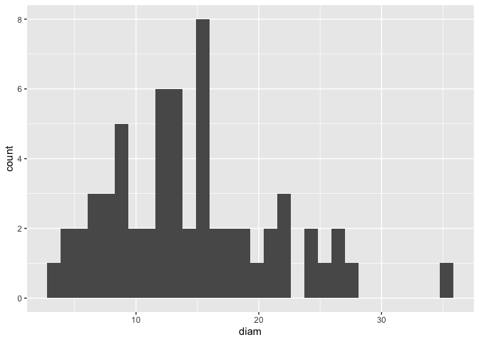

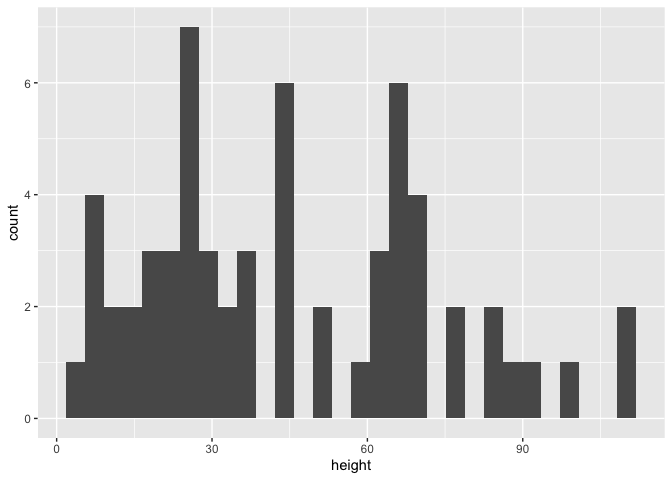

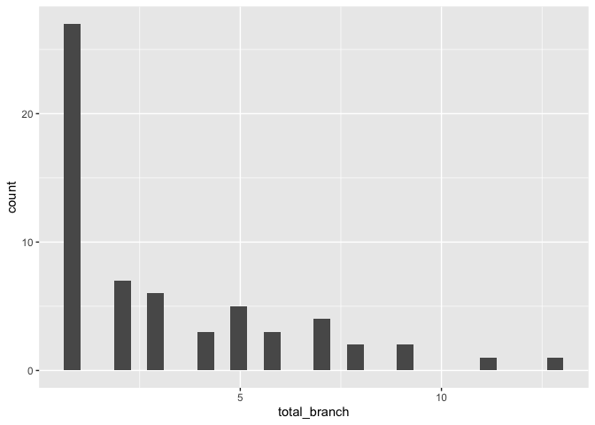

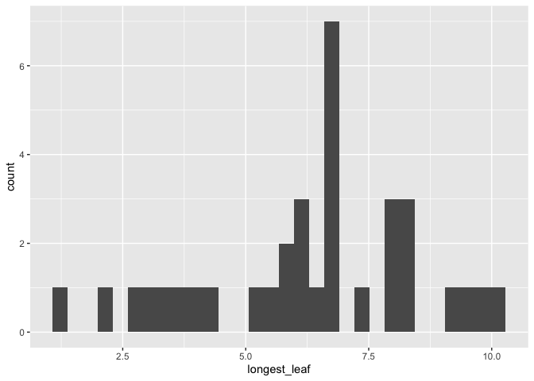

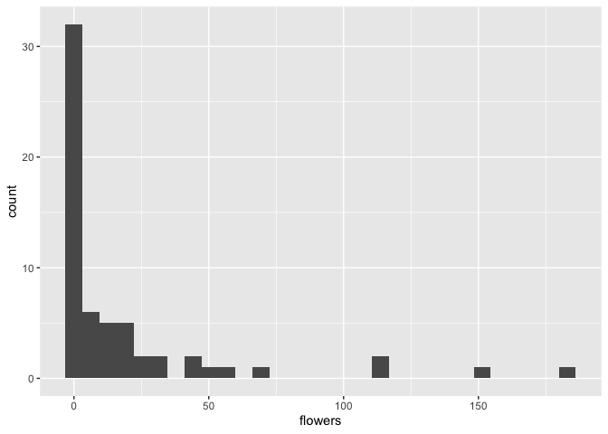

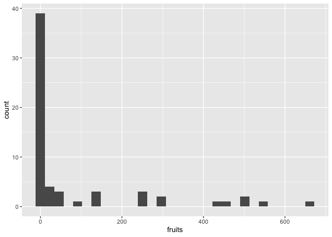

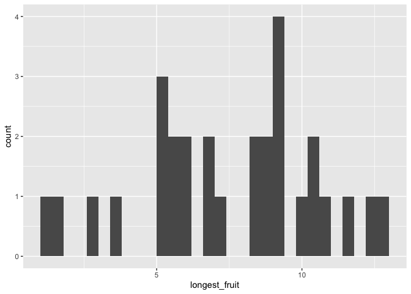

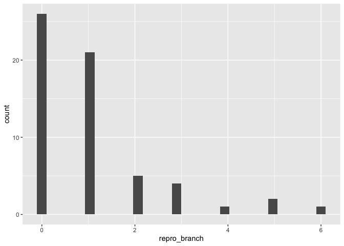

```r
anncensustrans_all_alive_max_elev_noinf <- as_tibble(anncensustrans_all_alive_max_elev_noinf) #convert to tibble so that the map function can use it

#Histograms
anncensustrans_all_alive_max_elev_noinf %>%
  select(diam, height, total_branch, longest_leaf, flowers, fruits, longest_fruit, repro_branch) %>%
  names() %>%
  map(~ggplot(anncensustrans_all_alive_max_elev_noinf, aes_string(x = .)) +
        geom_histogram())
```

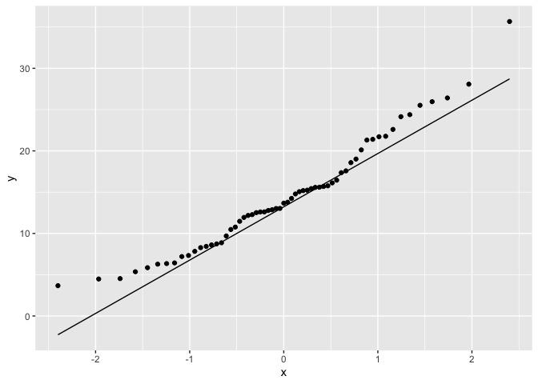

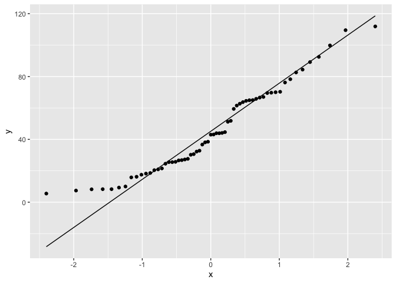

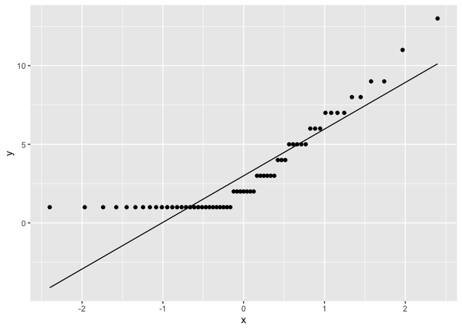

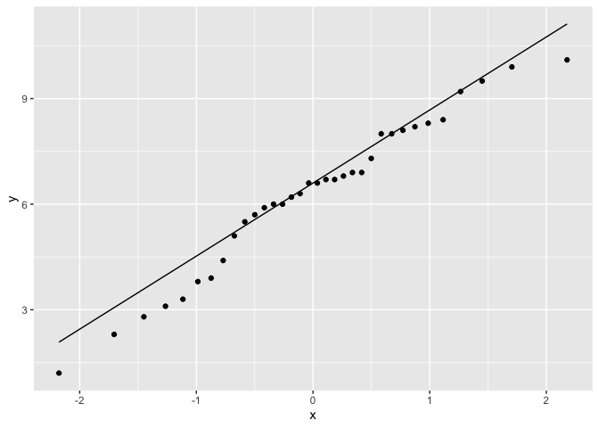

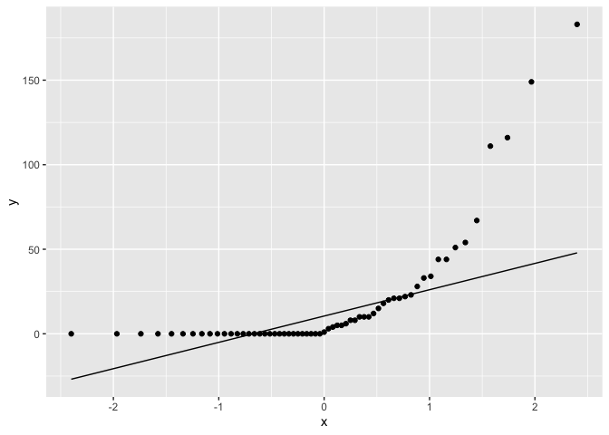

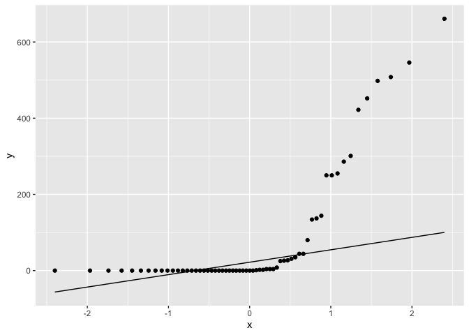

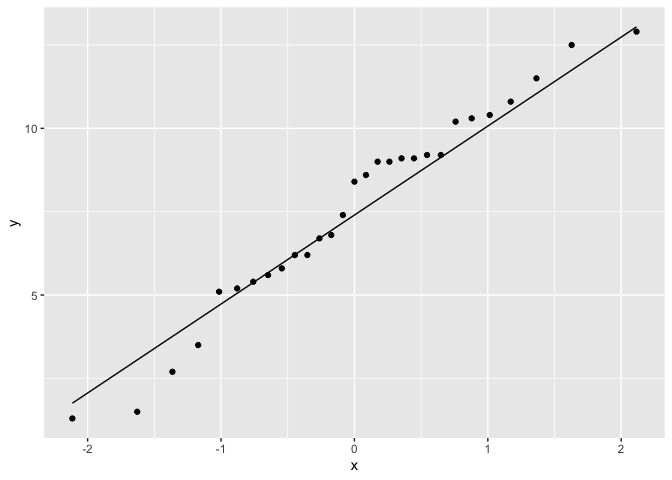

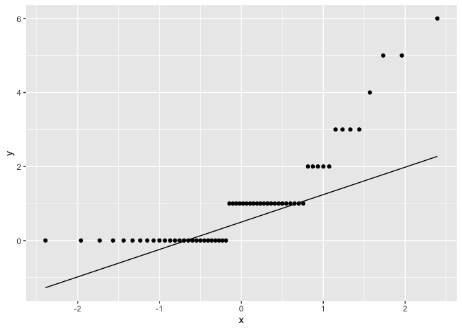

```r
#qq plots
anncensustrans_all_alive_max_elev_noinf %>%
  select(diam, height, total_branch, longest_leaf, flowers, fruits, longest_fruit, repro_branch) %>%
  names() %>%
  map(~ggplot(anncensustrans_all_alive_max_elev_noinf, aes_string(sample = .)) +
       stat_qq() +
        stat_qq_line())
```

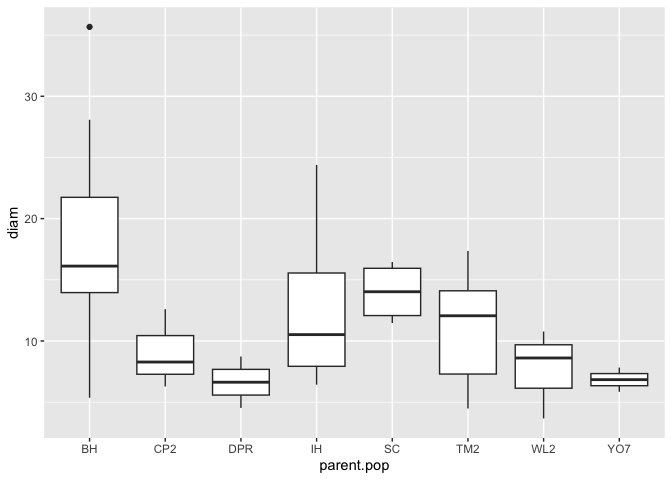

```r
# diam close to normal
# height close to normal
# total_branch heavily right skewed
# longest_leaf close to normal
# flowers heavily right skewed (0 inflated)
# fruits heavily right skewed (0 inflated)
# longest_fruit roughly normal, but low replication --> no stats
# repro_branch right skewed

#Transformations:
#anncensustrans_all_alive_max_elev_noinf %>% mutate(stbr = sqrt(total_branch)) %>% ggplot(aes(x=stbr)) + geom_histogram() #log, 1og10, and sqrt transformation didn't work

#anncensustrans_all_alive_max_elev_noinf %>% mutate(lrbr = log10(repro_branch)) %>% ggplot(aes(x=lrbr)) + geom_histogram() #log, 1og10, and sqrt transformation didn't work

#Box Plots
anncensustrans_all_alive_max_elev_noinf %>% ggplot(aes(x=parent.pop, y=diam)) + geom_boxplot()
```

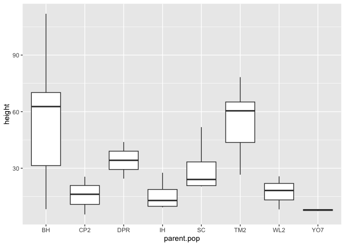

```r
anncensustrans_all_alive_max_elev_noinf %>% ggplot(aes(x=parent.pop, y=height)) + geom_boxplot()
```

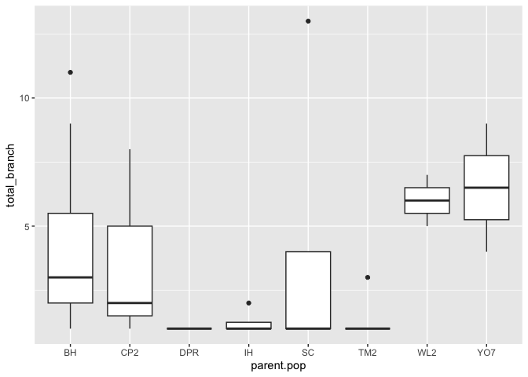

```r
anncensustrans_all_alive_max_elev_noinf %>% ggplot(aes(x=parent.pop, y=total_branch)) + geom_boxplot()
```

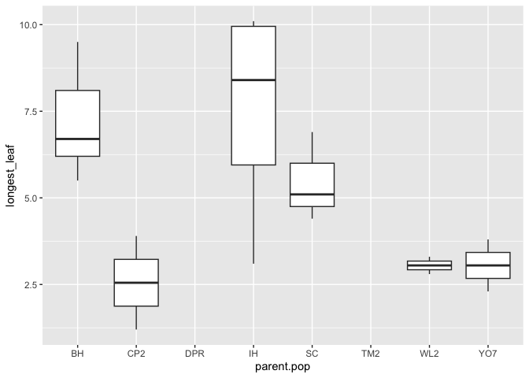

```r
anncensustrans_all_alive_max_elev_noinf %>% ggplot(aes(x=parent.pop, y=longest_leaf)) + geom_boxplot()
```

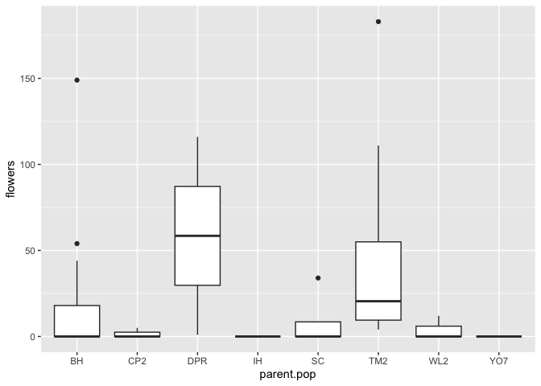

```r
anncensustrans_all_alive_max_elev_noinf %>% ggplot(aes(x=parent.pop, y=flowers)) + geom_boxplot()
```

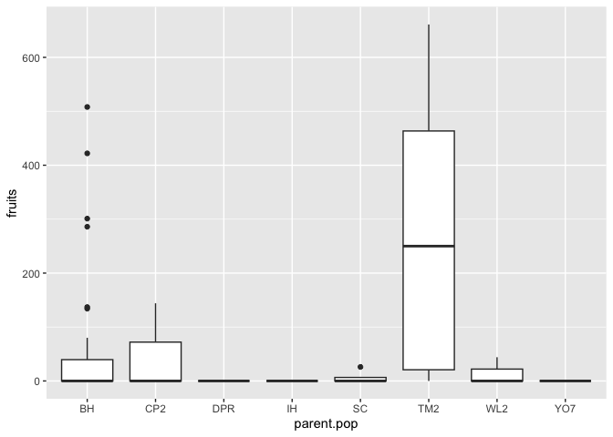

```r
anncensustrans_all_alive_max_elev_noinf %>% ggplot(aes(x=parent.pop, y=fruits)) + geom_boxplot()
```

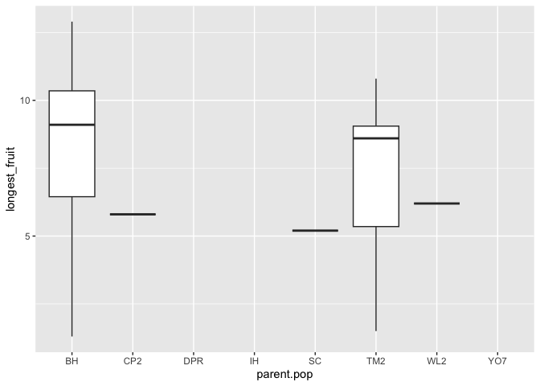

```r
anncensustrans_all_alive_max_elev_noinf %>% ggplot(aes(x=parent.pop, y=longest_fruit)) + geom_boxplot()
```

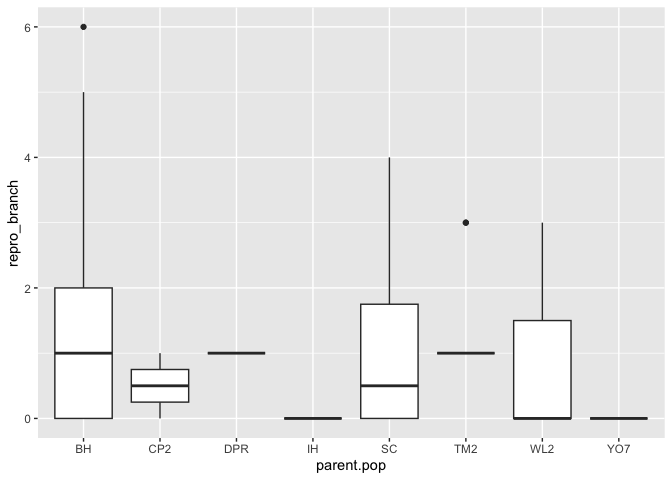

```r
anncensustrans_all_alive_max_elev_noinf %>% ggplot(aes(x=parent.pop, y=repro_branch)) + geom_boxplot()
```

```r
#variation across populations for diam, height, and longest leaf (maybe total_branch & repro_branch, not # flowers, prob not # fruits (all low except TM2), not longest_fruit)
```

## Relationships between traits

- Plot branching pattern with other size metrics for idea of shape

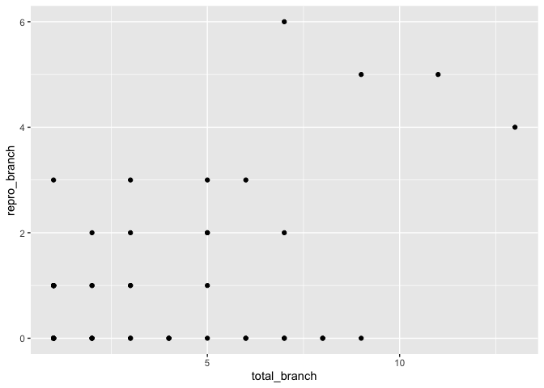

```r
anncensustrans_all_alive_max_elev_noinf %>% ggplot(aes(x=total_branch, y=repro_branch)) +
  geom_point()  #repro_branches is so 0 skewed it's hard to tell if there's a relationship
```

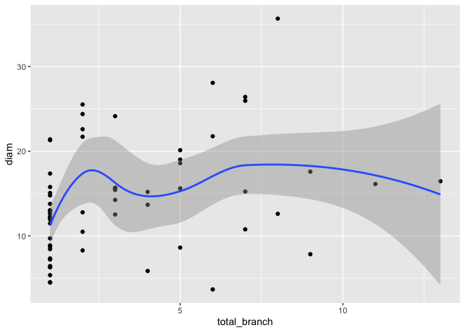

```r
anncensustrans_all_alive_max_elev_noinf %>% ggplot(aes(x=total_branch, y=diam)) +
  geom_point() +
  geom_smooth()
```

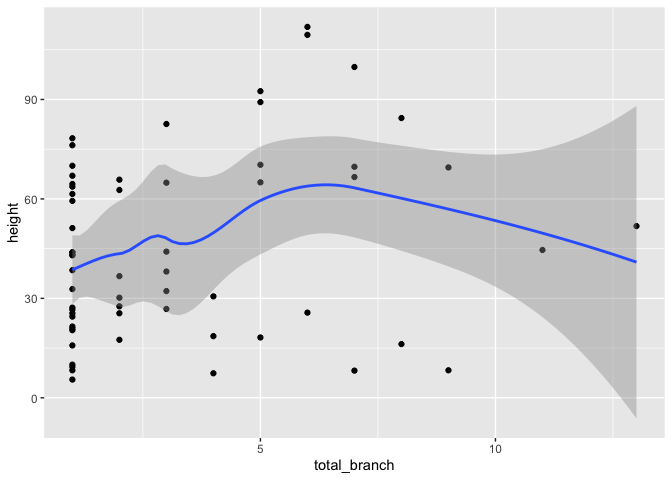

```r
anncensustrans_all_alive_max_elev_noinf %>% ggplot(aes(x=total_branch, y=height)) +
  geom_point() +
  geom_smooth()
```

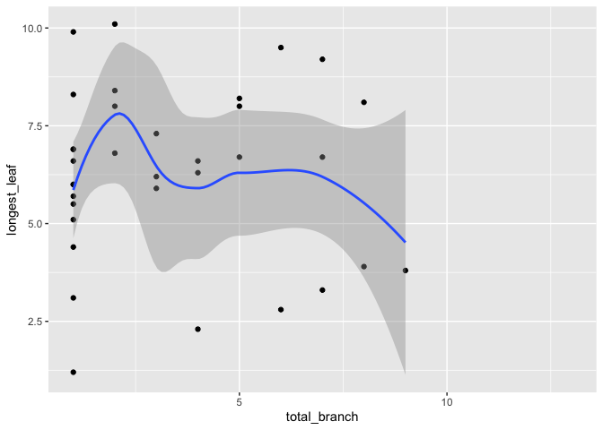

```r
anncensustrans_all_alive_max_elev_noinf %>% ggplot(aes(x=total_branch, y=longest_leaf)) +
  geom_point() +
  geom_smooth()
```

No clear relationships between branching and other size traits.

What about diameter and height?

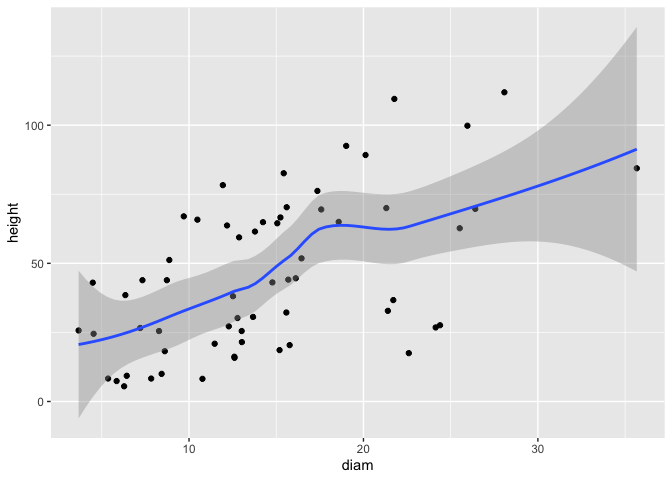

```r
anncensustrans_all_alive_max_elev_noinf %>% ggplot(aes(x=diam, y=height)) +
  geom_point() +
  geom_smooth()
```

There seems to be a positive relationship between height and diameter.

What about diameter and longest leaf?

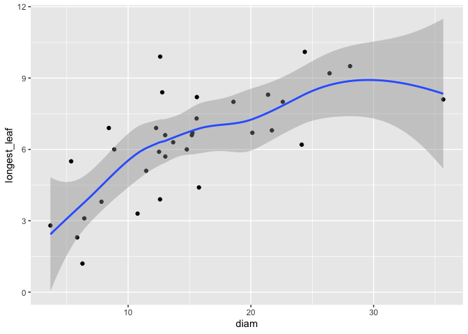

```r
anncensustrans_all_alive_max_elev_noinf %>% ggplot(aes(x=diam, y=longest_leaf)) +
  geom_point() +
  geom_smooth()
```

What about height and longest leaf?

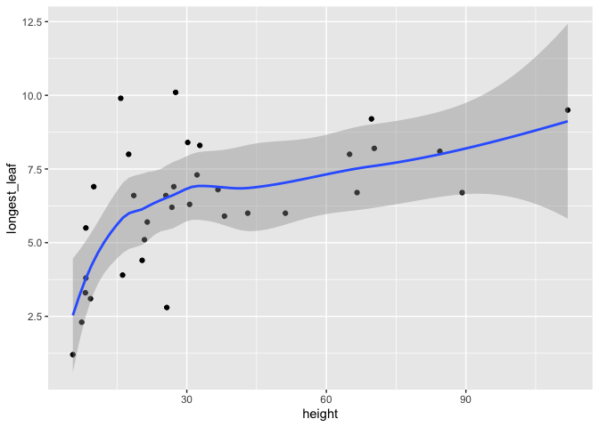

```r
anncensustrans_all_alive_max_elev_noinf %>% ggplot(aes(x=height, y=longest_leaf)) +
  geom_point() +
  geom_smooth()
```

Positive relationship between height and longest leaf seems to plateau.

## Relationships between Climate and Traits (fix this after figuring out climate data)

```r
names(anncensustrans_all_alive_max_elev)
ggplot(anncensustrans_all_alive_max_elev, aes(x = tmx, y = diam))+
  geom_point()

ggplot(anncensustrans_all_alive_max_elev, aes(x = ppt, y = diam))+
  geom_point()


ggplot(anncensustrans_all_alive_max_elev, aes(x = pck, y = diam))+
  geom_point()

ggplot(anncensustrans_all_alive_max_elev, aes(x = tmn, y = height))+
  geom_point()
ggplot(anncensustrans_all_alive_max_elev, aes(x = tmn, y = longest_leaf))+
  geom_point()
```

## Calculating means by pop (and elev)

```r
anncensustrans_all_alive_summary <- anncensustrans_all_alive_max_elev_noinf %>%
  group_by(parent.pop, elevation.group, elev_m) %>%
  summarise(meanDiam=mean(diam, na.rm = TRUE), sem_diam=sem(diam, na.rm=TRUE),
            meanHeight = mean(height,na.rm=(TRUE)), sem_height=sem(height, na.rm=(TRUE)),
            meanLongestLeaf=mean(longest_leaf, na.rm=(TRUE)), sem_leaf=sem(longest_leaf, na.rm=TRUE),
            meanTotBr=mean(total_branch, na.rm = TRUE), sem_totbr=sem(total_branch, na.rm=TRUE),
            meanRepBr=mean(repro_branch, na.rm=TRUE), semRepBr=sem(repro_branch, na.rm=TRUE),
            meanFruits=mean(fruits, na.rm = TRUE), semFruits=sem(fruits, na.rm=TRUE),
            meanLongFruit=mean(longest_fruit, na.rm = TRUE), semLongFruit=sem(longest_fruit, na.rm = TRUE),
            meanFl=mean(flowers, na.rm=TRUE), semFl=sem(flowers, na.rm=TRUE))
anncensustrans_all_alive_summary
```

```
## # A tibble: 8 × 19
## # Groups:   parent.pop, elevation.group [8]
##   parent.pop elevation.group elev_m meanDiam sem_diam meanHeight sem_height
##   <chr>      <chr>            <dbl>    <dbl>    <dbl>      <dbl>      <dbl>
## 1 BH         Low               511.    18.1      1.14      55.9        5.14
## 2 CP2        High             2244.     9.05     1.86      15.7        5.78
## 3 DPR        Mid              1019.     6.63     2.1       34.2        9.7
## 4 IH         Low               454.    13.0      4.02      15.7        4.23
## 5 SC         Low               422.    14.0      1.24      30.1        7.41
## 6 TM2        Low               379.    11.2      1.19      55.6        4.63
## 7 WL2        High             2020.     7.68     2.10      17.4        5.07
## 8 YO7        High             2470.     6.84     0.99       7.85       0.45
## # ℹ 12 more variables: meanLongestLeaf <dbl>, sem_leaf <dbl>, meanTotBr <dbl>,
## #   sem_totbr <dbl>, meanRepBr <dbl>, semRepBr <dbl>, meanFruits <dbl>,
## #   semFruits <dbl>, meanLongFruit <dbl>, semLongFruit <dbl>, meanFl <dbl>,
## #   semFl <dbl>
```

```r
#write_csv(anncensustrans_all_alive_summary, file ="../output/UCD_Traits/anncensus_traitavgs.csv")
anncensustrans_all_alive_max_elev_noinf %>% filter(parent.pop=="DPR") %>% select(flowers) #one DPR plant had 1 flower and the other had 116 (massive variation)
```

```
## # A tibble: 2 × 1
##   flowers
##     <dbl>
## 1     116
## 2       1
```

```r
anncensustrans_all_alive_max_elev_logregs <- anncensustrans_all_alive_max_elev_noinf %>%
  mutate(bTotBr=ifelse(total_branch==1, 0, 1),
         bRepBr=ifelse(repro_branch==0, 0, 1),
         bFruits=ifelse(fruits==0, 0, 1),
         bFlowers=ifelse(flowers==0, 0, 1))

anncensustrans_all_alive_summary_logregs <- anncensustrans_all_alive_max_elev_logregs %>%
  group_by(parent.pop, elevation.group, elev_m) %>%
  summarise(probTotBr = mean(bTotBr, na.rm = TRUE), sem_totbr=sem(bTotBr, na.rm = TRUE),
            probRepBr=mean(bRepBr, na.rm = TRUE), semRepBr=sem(bRepBr,na.rm = TRUE),
            probFruits=mean(bFruits, na.rm = TRUE), semFruits=sem(bFruits, na.rm = TRUE),
            probFlowers=mean(bFlowers, na.rm = TRUE), semFl=sem(bFlowers, na.rm = TRUE))
anncensustrans_all_alive_summary_logregs
```

```
## # A tibble: 8 × 11
## # Groups:   parent.pop, elevation.group [8]
##   parent.pop elevation.group elev_m probTotBr sem_totbr probRepBr semRepBr
##   <chr>      <chr>            <dbl>     <dbl>     <dbl>     <dbl>    <dbl>
## 1 BH         Low               511.    0.774     0.0763     0.516   0.0912
## 2 CP2        High             2244.    0.667     0.333      0.5     0.5
## 3 DPR        Mid              1019.    0         0          1       0
## 4 IH         Low               454.    0.25      0.25       0       0
## 5 SC         Low               422.    0.25      0.25       0.5     0.289
## 6 TM2        Low               379.    0.0833    0.0833     1       0
## 7 WL2        High             2020.    1         0          0.333   0.333
## 8 YO7        High             2470.    1         0          0       0
## # ℹ 4 more variables: probFruits <dbl>, semFruits <dbl>, probFlowers <dbl>,
## #   semFl <dbl>
```

```r
#write_csv(anncensustrans_all_alive_summary_logregs, file ="../output/UCD_Traits/anncensus_traitprobs.csv")
```

## Mixed Effects Models (and figures of trait means)

### Diam

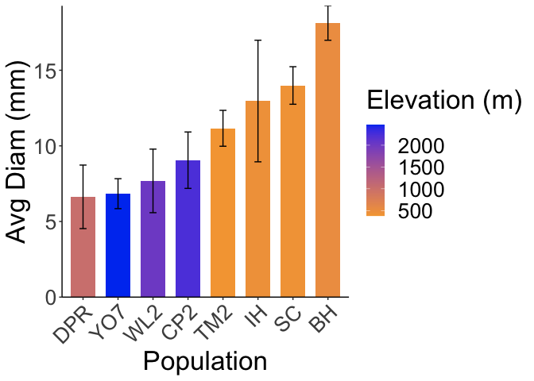

```r
anncensustrans_all_alive_summary %>% ggplot(aes(x=fct_reorder(parent.pop, meanDiam), y=meanDiam, fill=elev_m)) +
  geom_col(width = 0.7,position = position_dodge(0.75)) +
  geom_errorbar(aes(ymin=meanDiam-sem_diam,ymax=meanDiam+sem_diam),width=.2, position =
                  position_dodge(0.75)) +
  scale_y_continuous(expand = c(0, 0)) +
  #scale_fill_manual(values=elev_three_palette) +
  scale_fill_gradient(low = "#F5A540", high = "#0043F0") +
  labs(fill="Elevation (m)", y="Avg Diam (mm)", x="Population") +
   theme_classic() +
  theme(text=element_text(size=25), axis.text.x = element_text(angle = 45,  hjust = 1))
```

```r
#ggsave("../output/UCD_Traits/AvgDiam.png", width = 8, height = 6, units = "in")

lmediam2 = lmerTest::lmer(diam ~ (1|parent.pop/mf), data=anncensustrans_all_alive_max_elev_noinf)
summary(lmediam2)
```

```
## Linear mixed model fit by REML. t-tests use Satterthwaite's method [
## lmerModLmerTest]
## Formula: diam ~ (1 | parent.pop/mf)
##    Data: anncensustrans_all_alive_max_elev_noinf
##
## REML criterion at convergence: 387.7
##
## Scaled residuals:
##     Min      1Q  Median      3Q     Max
## -2.1416 -0.6903 -0.1557  0.5869  3.2580
##
## Random effects:
##  Groups        Name        Variance Std.Dev.
##  mf:parent.pop (Intercept)  0.8998  0.9486
##  parent.pop    (Intercept) 12.5710  3.5456
##  Residual                  30.1273  5.4888
## Number of obs: 61, groups:  mf:parent.pop, 25; parent.pop, 8
##
## Fixed effects:
##             Estimate Std. Error     df t value Pr(>|t|)
## (Intercept)   11.605      1.594  8.249   7.279 7.33e-05 ***
## ---
## Signif. codes:  0 '***' 0.001 '**' 0.01 '*' 0.05 '.' 0.1 ' ' 1
```

```r
ranova(lmediam2) #no maternal family effect b/c maybe not enough individuals
```

```
## ANOVA-like table for random-effects: Single term deletions
##
## Model:
## diam ~ (1 | mf:parent.pop) + (1 | parent.pop)
##                     npar  logLik    AIC    LRT Df Pr(>Chisq)
## <none>                 4 -193.83 395.67
## (1 | mf:parent.pop)    3 -193.85 393.70 0.0362  1     0.8490
## (1 | parent.pop)       3 -197.02 400.04 6.3709  1     0.0116 *
## ---
## Signif. codes:  0 '***' 0.001 '**' 0.01 '*' 0.05 '.' 0.1 ' ' 1
```

```r
#could try assigning unique names and "un-nesting" them
VarCorr(lmediam2) %>%
  as.data.frame() %>%
  mutate(var.pct = vcov/sum(vcov)*100)
```

```
##             grp        var1 var2       vcov     sdcor   var.pct
## 1 mf:parent.pop (Intercept) <NA>  0.8998274 0.9485923  2.063912
## 2    parent.pop (Intercept) <NA> 12.5709953 3.5455599 28.833789
## 3      Residual        <NA> <NA> 30.1273156 5.4888355 69.102298
```

```r
#EMM_diam=emmeans(lmediam2,pairwise~parent.pop)
#EMM_diam

#COME BACK TO THE BELOW WHEN CLIMATE DATA FIGURED OUT
#lmediam3 = lmer(diam ~ ppt + (1|parent.pop/mf), #data=anncensustrans_all_alive_max_elev_noinf)
#summary(lmediam3)
#ranova(lmediam3)
##singular warning b/c we only have one value for each pop #(multiple maternal families have one value)
#
#lmediam4 = lmer(diam ~ ppt + (1|parent.pop), #data=anncensustrans_all_alive_max_elev_noinf)
#summary(lmediam4)
#ranova(lmediam4)
```

### Total_branch

- Tried code for poisson regression or logistic regression with mixed effects
  - Had to use glmer for this
    - Used family = poisson for traits with poisson distribution
      - Couldn’t use ranova so used a loglikihood test to test for the significance of the random effects
    - Use family = binomial(logit) for logit link
      - Tried family = binomial for Prob_Total_Branch (1 or greater than 1). Couldn’t include random effects so parent.pop is in the model as a fixed effect.

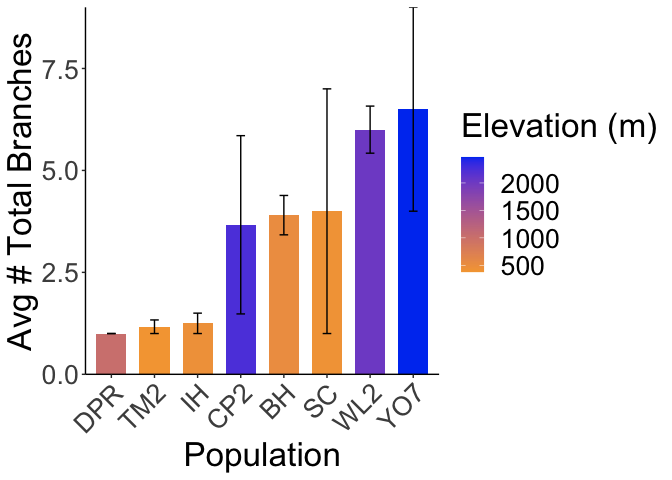

```r
anncensustrans_all_alive_summary %>% ggplot(aes(x=fct_reorder(parent.pop, meanTotBr), y=meanTotBr, fill=elev_m)) +
  geom_col(width = 0.7,position = position_dodge(0.75)) +
  geom_errorbar(aes(ymin=meanTotBr-sem_totbr,ymax=meanTotBr+sem_totbr),width=.2, position =
                  position_dodge(0.75)) +
  scale_y_continuous(expand = c(0, 0)) +
  #scale_fill_manual(values=elev_three_palette) +
  scale_fill_gradient(low = "#F5A540", high = "#0043F0") +
  labs(fill="Elevation (m)", x="Population", y="Avg # Total Branches") +
   theme_classic() +
  theme(text=element_text(size=25), axis.text.x = element_text(angle = 45,  hjust = 1)) #large standard error bars
```

```r
#ggsave("../output/UCD_Traits/AvgTotBsBr.png", width = 8, height = 6, units = "in")

#Poisson regression
lmetotal_branch <- glmer(total_branch ~ (1|parent.pop/mf), data = anncensustrans_all_alive_max_elev_noinf, family = poisson(link = "log"))
summary(lmetotal_branch)
```

```
## Generalized linear mixed model fit by maximum likelihood (Laplace
##   Approximation) [glmerMod]
##  Family: poisson  ( log )
## Formula: total_branch ~ (1 | parent.pop/mf)
##    Data: anncensustrans_all_alive_max_elev_noinf
##
##      AIC      BIC   logLik deviance df.resid
##    282.2    288.6   -138.1    276.2       58
##
## Scaled residuals:
##     Min      1Q  Median      3Q     Max
## -1.8675 -0.7445 -0.2390  0.7347  3.3455
##
## Random effects:
##  Groups        Name        Variance Std.Dev.
##  mf:parent.pop (Intercept) 0.1572   0.3965
##  parent.pop    (Intercept) 0.2877   0.5364
## Number of obs: 61, groups:  mf:parent.pop, 25; parent.pop, 8
##
## Fixed effects:
##             Estimate Std. Error z value Pr(>|z|)
## (Intercept)   0.9970     0.2401   4.152 3.29e-05 ***
## ---
## Signif. codes:  0 '***' 0.001 '**' 0.01 '*' 0.05 '.' 0.1 ' ' 1
```

```r
VarCorr(lmetotal_branch) %>%
  as.data.frame() %>%
  mutate(var.pct = vcov/sum(vcov)*100)
```

```
##             grp        var1 var2      vcov     sdcor var.pct
## 1 mf:parent.pop (Intercept) <NA> 0.1571879 0.3964692 35.3307
## 2    parent.pop (Intercept) <NA> 0.2877166 0.5363922 64.6693
```

```r
glance(lmetotal_branch)
```

```
## # A tibble: 1 × 7
##    nobs sigma logLik   AIC   BIC deviance df.residual
##   <int> <dbl>  <dbl> <dbl> <dbl>    <dbl>       <int>
## 1    61     1  -138.  282.  289.     67.8          58
```

```r
#ranova(lmetotal_branch) doesn't work for lme4
#to test for significance of random effect: https://bbolker.github.io/mixedmodels-misc/glmmFAQ.html#testing-significance-of-random-effects
#the most common way to do this is to use a likelihood ratio test, i.e. fit the full and reduced models (the reduced model is the model with the focal variance(s) set to zero).
m0 <- glmer(total_branch ~ (1|parent.pop), data = anncensustrans_all_alive_max_elev_noinf, family = poisson(link = "log"))
m00 <- lm(total_branch~1, anncensustrans_all_alive_max_elev_noinf)
anova(lmetotal_branch,m0, m00) #model with both random effects has a higher likelihood (better fit)
```

```
## Data: anncensustrans_all_alive_max_elev_noinf
## Models:
## m0: total_branch ~ (1 | parent.pop)
## m00: total_branch ~ 1
## lmetotal_branch: total_branch ~ (1 | parent.pop/mf)
##                 npar    AIC    BIC  logLik deviance  Chisq Df Pr(>Chisq)
## m0                 2 284.10 288.32 -140.05   280.10
## m00                2 306.68 310.90 -151.34   302.68  0.000  0
## lmetotal_branch    3 282.22 288.55 -138.11   276.22 26.459  1  2.691e-07 ***
## ---
## Signif. codes:  0 '***' 0.001 '**' 0.01 '*' 0.05 '.' 0.1 ' ' 1
```

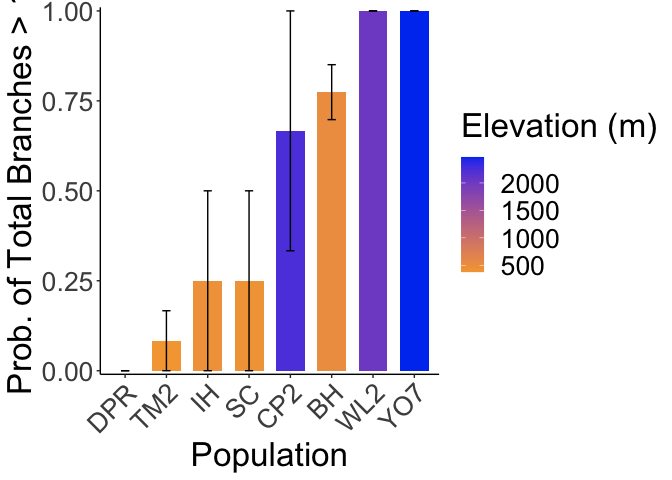

```r
anncensustrans_all_alive_summary_logregs %>% ggplot(aes(x=fct_reorder(parent.pop, probTotBr), y=probTotBr, fill=elev_m)) +
  geom_col(width = 0.7,position = position_dodge(0.75)) +
  geom_errorbar(aes(ymin=probTotBr-sem_totbr,ymax=probTotBr+sem_totbr),width=.2, position =
                  position_dodge(0.75)) +
  scale_y_continuous(expand = c(0, 0.01)) +
  #scale_fill_manual(values=elev_three_palette) +
  scale_fill_gradient(low = "#F5A540", high = "#0043F0") +
  labs(fill="Elevation (m)", x="Population", y="Prob. of Total Branches > 1") +
   theme_classic() +
  theme(text=element_text(size=25), axis.text.x = element_text(angle = 45,  hjust = 1))
```

```r
#ggsave("../output/UCD_Traits/ProbTotBsBr.png", width = 8, height = 6, units = "in")

totbr_logreg=glm(bTotBr ~ parent.pop, data=anncensustrans_all_alive_max_elev_logregs, family = binomial())
summary(totbr_logreg) #this is not the correct model b/c it treats parent pop as a fixed effect and doesn't take into account maternal families
```

```
##
## Call:
## glm(formula = bTotBr ~ parent.pop, family = binomial(), data = anncensustrans_all_alive_max_elev_logregs)
##
## Coefficients:
##                Estimate Std. Error z value Pr(>|z|)
## (Intercept)      1.2321     0.4296   2.868  0.00413 **
## parent.popCP2   -0.5390     1.2979  -0.415  0.67793
## parent.popDPR  -19.7982  4612.2020  -0.004  0.99658
## parent.popIH    -2.3308     1.2320  -1.892  0.05851 .
## parent.popSC    -2.3308     1.2320  -1.892  0.05851 .
## parent.popTM2   -3.6300     1.1294  -3.214  0.00131 **
## parent.popWL2   17.3339  3765.8472   0.005  0.99633
## parent.popYO7   17.3339  4612.2020   0.004  0.99700
## ---
## Signif. codes:  0 '***' 0.001 '**' 0.01 '*' 0.05 '.' 0.1 ' ' 1
##
## (Dispersion parameter for binomial family taken to be 1)
##
##     Null deviance: 83.759  on 60  degrees of freedom
## Residual deviance: 52.818  on 53  degrees of freedom
## AIC: 68.818
##
## Number of Fisher Scoring iterations: 17
```